**Instructor copy.** Executed notebook with all results shown, including the "after your attempt" cells. Projector/offline fallback; learners should use the notebook itself.

# f4p · Linear programmes from scratch (optional LP primer)

**In plain words.** A linear programme (LP) chooses some amounts, keeps a few rules and makes a total as small as possible. In this notebook you solve one by hand, then let SciPy solve it, read every number it returns, and check those numbers yourself. At the end you rename two columns and the same code solves the menu of advanced step 10.

**Learning goals.** After this notebook you can

1. name the variables, the objective and the rules of a small LP, and write it for `scipy.optimize.linprog`;
2. read `linprog`'s answer: status, amounts, best total and prices, with their signs;
3. check an answer yourself: the rules hold, no amount is negative, and a straight line under all candidates proves that nothing is cheaper;
4. check a price by solving again with a nudged rule, and see where the check stops working;
5. (dive deeper) solve the companion problem about prices, and meet an unbounded problem and prices that are not unique.

**What you need.** The LP primer page of the course, or at least its problem. The lever rule. No derivatives and no matrix algebra beyond "multiply and add".

| Section | What | Track | Time |
| --- | --- | --- | --- |
| 1 | Every pair, by hand | main | 10 min |
| 2 | The same problem in `linprog` | main | 15 min |
| 3 | The search, one swap at a time | main | 10 min |
| 4 | Prices, and a line under every lot | main | 15 min |
| 5 | The textbook picture | main | 15 min |
| 6 | Same problem, new names: step 10's menu | main | 5 min |
| 7 | The companion problem about prices | dive deeper | 10 min |
| 8 | Unbounded, and prices that are not unique | dive deeper | 10 min |
| 9 | Exercises | both | 20 min |

**Coming from materials.** You have done the hand part before: the lever rule of step 03 and the chord rule. The new parts are the solver's view and the idea that a line under all candidates is a proof.

**Coming from operations research.** You can skip this notebook. Its conventions: amounts are `f` (in this course `x` is a composition), masters (the course's LPs over a list of phase states) are minimisations with equality rows, and SciPy's marginals are the change of the optimum per unit increase of a right-hand side.

**The numbers are invented** for the exercise (prices, contents, caps); they are not market data.

**How to work.** Run the cells from top to bottom. In each "Your turn" cell, replace `None` with your value and run it: `check` says whether you match, without showing the answer. Cells marked *After your attempt* hold worked solutions.

```python
# Setup: run this cell first. Locally it finds the course folder; in Colab it
# downloads the tested course release and the locked package versions.
# In Colab, the first run then restarts the session on purpose and Colab reports
# a crash: that is expected. Run this cell again, then the rest of the notebook.
RELEASE = "main"
import os, pathlib, subprocess, sys, time
ROOT = next((p for p in (pathlib.Path.cwd(), *pathlib.Path.cwd().parents)
             if (p / "pyproject.toml").is_file() and (p / "course").is_dir()), None)
if ROOT is None and "google.colab" in sys.modules:
    ROOT = pathlib.Path("/content/CalphadIntro")
    if not ROOT.is_dir():
        clone = ["git", "clone", "-q", "--depth", "1", "--branch", RELEASE,
                 "https://github.com/ukerzel/CalphadIntro.git", str(ROOT)]
        git = dict(os.environ, GIT_TERMINAL_PROMPT="0")
        if subprocess.run(clone, env=git, capture_output=True).returncode:
            raise SystemExit(f"Could not download course release {RELEASE}: check the internet "
                             "connection and run this cell again.")
    if not (ROOT / ".colab-ready").exists():
        if subprocess.run([sys.executable, "-m", "pip", "install", "-q", "-r",
                           str(ROOT / "notebooks" / "requirements-colab.txt")]).returncode:
            raise SystemExit("Installing the course packages failed; run this cell again.")
        (ROOT / ".colab-ready").touch()
        # Colab has already loaded its own numpy; a fresh session is needed to use the installed versions.
        print("Installed the course's package versions. Colab now restarts this session and"
              " reports a crash; that is expected. When it has reconnected, run this cell again"
              " (it will not install twice), then the rest of the notebook.", flush=True)
        time.sleep(3)
        os.kill(os.getpid(), 9)
if ROOT is None:
    raise SystemExit("Open this notebook from the course folder (poetry run jupyter lab) or in Colab.")
os.chdir(ROOT)
sys.path.insert(0, str(ROOT))
from notebooks.helpers import check, confirm, database, show_versions
show_versions(RELEASE)
```

```
Course release main · Python 3.12.14
  numpy       2.5.3
  scipy       1.18.1
  matplotlib  3.11.2
  xarray      2026.7.0
  pycalphad   0.11.2
```

```
True
```

## 0. Numbers you may change, and the tools

A melt shop must make 1 kg of a copper–nickel alloy with exactly 0.40 kg of nickel, as cheaply as possible. Each lot of scrap has a nickel content `w` (kg Ni per kg of lot) and a price (€ per kg). Leave the numbers as they are for the first run: the "Your turn" checks expect them. Later, change one number at a time and rerun everything below it.

```python
NAMES  = ["Cu", "CuNi10", "CuNi30", "CuNi45", "Monel", "Ni"]   # short names of the six lots
W      = [0.00, 0.10, 0.30, 0.45, 0.65, 1.00]                   # Ni content, kg Ni per kg of lot
PRICE  = [7.40, 7.90, 8.40, 10.00, 10.20, 15.50]                 # € per kg of lot
TARGET = 0.40                                                    # kg Ni per kg of charge
```

Three libraries. `numpy` for lists of numbers, `matplotlib` for pictures and `linprog` from SciPy, the LP solver. Colours follow the website.

```python
import numpy as np
import matplotlib.pyplot as plt
from scipy.optimize import linprog

LOT_C, LINE_C, MIN_C, BAD_C = "#2445c4", "#8f6400", "#b58900", "#cf4418"   # the website's colours
W, PRICE = np.array(W), np.array(PRICE)
for name, w, price in zip(NAMES, W, PRICE):
    print(f"{name:7s} w = {w:.2f} kg Ni per kg   price = {price:5.2f} € per kg")
```

```
Cu      w = 0.00 kg Ni per kg   price =  7.40 € per kg
CuNi10  w = 0.10 kg Ni per kg   price =  7.90 € per kg
CuNi30  w = 0.30 kg Ni per kg   price =  8.40 € per kg
CuNi45  w = 0.45 kg Ni per kg   price = 10.00 € per kg
Monel   w = 0.65 kg Ni per kg   price = 10.20 € per kg
Ni      w = 1.00 kg Ni per kg   price = 15.50 € per kg
```

## 1. Every pair, by hand (main track, 10 min)

Two lots, one below the target and one above, make 1 kg at the target. The lever rule fixes the amounts:

$$f_{\text{rich}}=\frac{\text{target}-w_{\text{poor}}}{w_{\text{rich}}-w_{\text{poor}}},\qquad f_{\text{poor}}=1-f_{\text{rich}},$$

and the charge costs $f_{\text{poor}}\,c_{\text{poor}}+f_{\text{rich}}\,c_{\text{rich}}$. Two lots on the same side of the target would need a negative amount, which cannot be bought.

### Your turn: one charge

What does 1 kg at 0.40 cost when it is made of copper scrap (Cu) and Monel offcuts? Use the lever rule and the printed prices.

```python
cost_cu_monel = None   # € per kg
check(cost_cu_monel, "f4p_cu_monel")
```

```
f4p_cu_monel: not attempted yet. Replace None with your value and run the cell again.
```

**Predict first.** Which pair do you expect to be cheapest? The next cell tries every pair with a plain double loop.

```python
best = None
for i in range(len(W)):
    if W[i] == TARGET:                                 # a single lot already at the target
        print(f"{NAMES[i]:7s} alone      amount 1.000 kg           cost {PRICE[i]:6.3f} €")
        if best is None or PRICE[i] < best[0]:
            best = (PRICE[i], i, i, 1.0)
    for j in range(len(W)):
        if W[i] < TARGET < W[j]:                       # one lot below the target, one above
            f_rich = (TARGET - W[i]) / (W[j] - W[i])   # lever rule
            cost = (1 - f_rich) * PRICE[i] + f_rich * PRICE[j]
            print(f"{NAMES[i]:7s} + {NAMES[j]:7s}  amounts {1 - f_rich:.3f} + {f_rich:.3f} kg   cost {cost:6.3f} €")
            if best is None or cost < best[0]:
                best = (cost, i, j, f_rich)
print(f"\ncheapest: {' + '.join(dict.fromkeys([NAMES[best[1]], NAMES[best[2]]]))}, {best[0]:.3f} € per kg")
```

```
Cu      + CuNi45   amounts 0.111 + 0.889 kg   cost  9.711 €
Cu      + Monel    amounts 0.385 + 0.615 kg   cost  9.123 €
Cu      + Ni       amounts 0.600 + 0.400 kg   cost 10.640 €
CuNi10  + CuNi45   amounts 0.143 + 0.857 kg   cost  9.700 €
CuNi10  + Monel    amounts 0.455 + 0.545 kg   cost  9.155 €
CuNi10  + Ni       amounts 0.667 + 0.333 kg   cost 10.433 €
CuNi30  + CuNi45   amounts 0.333 + 0.667 kg   cost  9.467 €
CuNi30  + Monel    amounts 0.714 + 0.286 kg   cost  8.914 €
CuNi30  + Ni       amounts 0.857 + 0.143 kg   cost  9.414 €

cheapest: CuNi30 + Monel, 8.914 € per kg
```

A picture of the same thing: lots as dots, price against content. A two-lot charge at the target costs the height of the chord between the two dots at the target, so the cheapest charge is the chord whose height at 0.40 is lowest.

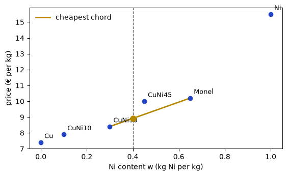

```python
fig, ax = plt.subplots(figsize=(6.4, 3.6))
ax.scatter(W, PRICE, color=LOT_C, zorder=3)
for name, w, price in zip(NAMES, W, PRICE):
    ax.annotate(name, (w, price), textcoords="offset points", xytext=(5, 6), fontsize=9)
i, j = best[1], best[2]
ax.plot([W[i], W[j]], [PRICE[i], PRICE[j]], color=MIN_C, lw=2, label="cheapest chord")
ax.axvline(TARGET, color="0.4", ls="--", lw=1)
ax.plot(TARGET, best[0], "o", color=MIN_C, ms=8, zorder=4)
ax.set_xlabel("Ni content w (kg Ni per kg)"); ax.set_ylabel("price (€ per kg)"); ax.legend(frameon=False)
plt.show()
```

## 2. The same problem in `linprog` (main track, 15 min)

The three parts of the problem, in plain words and then in symbols:

- **choose** the amounts $f_j\ge0$ of every lot $j$, in kg (the variables);
- **to make** the total cost $\sum_j f_j\,c_j$ as small as possible (the objective);
- **while keeping** the rules $\sum_j f_j=1$ (1 kg) and $\sum_j f_j\,w_j=0.40$ (0.40 kg nickel); these are the constraints.

In one line: minimise $\sum_j f_jc_j$ **subject to** $\sum_j f_j=1$, $\sum_j f_jw_j=0.40$, $f_j\ge0$. "Subject to" means "while keeping these rules".

`linprog` takes the problem as arrays. `c` holds one cost per lot. Each row of `A_eq` is one rule, each column one lot: the rule says "this row times the amounts equals the matching entry of `b_eq`". `bounds=(0, None)` says that no amount is negative. `method="highs-ds"` asks for the dual simplex method (the mirror image of the swap search in section 3: it keeps a line under every lot and swaps until the used pair can make the target), which returns a corner answer: at most as many non-zero amounts as rules.

```python
c = PRICE                                   # objective: cost of 1 kg of each lot
A_eq = np.array([np.ones(len(W)),           # rule 1: the amounts add up ...
                 W])                        # rule 2: the nickel adds up ...
b_eq = np.array([1.0, TARGET])              # ... to 1 kg and to 0.40 kg
print("        " + "".join(f"{n:>8s}" for n in NAMES) + "      b_eq")
for name, row, rhs in zip(["1 kg", "Ni"], A_eq, b_eq):
    print(f"{name:6s}  " + "".join(f"{v:8.2f}" for v in row) + f"   = {rhs:.2f}")
print("cost    " + "".join(f"{v:8.2f}" for v in c))
```

```
              Cu  CuNi10  CuNi30  CuNi45   Monel      Ni      b_eq
1 kg        1.00    1.00    1.00    1.00    1.00    1.00   = 1.00
Ni          0.00    0.10    0.30    0.45    0.65    1.00   = 0.40
cost        7.40    7.90    8.40   10.00   10.20   15.50
```

```python
res = linprog(c, A_eq=A_eq, b_eq=b_eq, bounds=(0, None), method="highs-ds")
print("status: ", res.status, "-", res.message)   # 0 means: a best answer was found
```

```
status:  0 - Optimization terminated successfully. (HiGHS Status 7: Optimal)
```

Read `res.status` first: 0 optimal, 2 infeasible (no choice keeps every rule), 3 unbounded (the total can fall without limit). Other codes mean the solver stopped early or ran into numerical trouble; read `res.message`. Only for status 0 are the other numbers an answer.

- `res.x` holds the **amounts**, despite its name. In this course $x$ is a composition, so we copy it into `f` at once;
- `res.fun` is the best total.

```python
f = res.x                                   # amounts in kg; "x" is SciPy's name, not a composition
for name, amount in zip(NAMES, f):
    if amount > 1e-12:
        print(f"buy {amount:.4f} kg of {name}")
print(f"best cost: {res.fun:.4f} € per kg")
```

```
buy 0.7143 kg of CuNi30
buy 0.2857 kg of Monel
best cost: 8.9143 € per kg
```

Two checks every LP answer must pass, whoever solved it: the rules hold and no amount is negative. The messages say in words what went wrong if a check fails.

```python
assert abs(f.sum() - 1) < 1e-9, f"the amounts add to {f.sum():.6f} kg, not 1"
assert abs(f @ W - TARGET) < 1e-9, f"the charge holds {f @ W:.6f} kg Ni, not {TARGET}"   # @: multiply and add
assert f.min() > -1e-12, f"a negative amount: {f.min():.3g}"
if (list(W), list(PRICE), TARGET) == ([0.0, 0.1, 0.3, 0.45, 0.65, 1.0], [7.4, 7.9, 8.4, 10.0, 10.2, 15.5], 0.40):
    confirm(res.fun, 8.914286, "The cheapest charge", tol=1e-5)
else:
    print("You changed the numbers in section 0: no lesson value to compare with.")
```

```
✓ The cheapest charge reproduces the lesson value.
```

### Your turn: how many lots?

How many lots does the cheapest charge use? Why can a corner answer of this problem never use more?

```python
lots_used = None   # a whole number
check(lots_used, "f4p_lots_used")
```

```
f4p_lots_used: not attempted yet. Replace None with your value and run the cell again.
```

*After your attempt.* Two lots. A charge of three lots at 0.40 is a mixture of two-lot charges, each at 0.40 (pair each lot below 0.40 with one above), and the cheaper of those costs no more than the mixture. With two rules a best charge never needs more than two lots; a corner answer has at most as many non-zero amounts as rules.

## 3. The search, one swap at a time (main track, 10 min)

Trying every pair works for six lots, not for thousands. A solver searches:

1. start from a pair that can make the charge, here Cu and Ni;
2. draw the line through the two used lots; for every lot compute its price minus the line's height at its content (its *gap*);
3. if no gap is negative, stop. Otherwise the lot with the most negative gap comes in, and the used lot on the same side of the target goes out (only that swap keeps both amounts positive). Go to 2.

This is the (primal) simplex method on a two-rule problem. The cost never rises.

```python
used = [0, 5]                                          # Cu and Ni: indices into the lists above
for round_ in range(1, 10):
    a, b = used
    slope = (PRICE[b] - PRICE[a]) / (W[b] - W[a])      # the line through the two used lots
    base = PRICE[a] - slope * W[a]                     # its height at w = 0
    gap = PRICE - (base + slope * W)                   # price minus line, for every lot
    f_b = (TARGET - W[a]) / (W[b] - W[a])
    cost = (1 - f_b) * PRICE[a] + f_b * PRICE[b]
    print(f"round {round_}: {NAMES[a]} + {NAMES[b]}, cost {cost:.3f} €; gaps " + ", ".join(f"{n} {g:+.3f}" for n, g in zip(NAMES, gap)))
    enter = int(np.argmin(gap))
    if gap[enter] > -1e-9:
        print("no lot below the line: done")
        break
    leave = a if (W[a] - TARGET) * (W[enter] - TARGET) > 0 else b   # the used lot on the entering lot's side
    print(f"         {NAMES[enter]} comes in, {NAMES[leave]} goes out")
    used = sorted([k for k in used if k != leave] + [enter], key=lambda k: W[k])
```

```
round 1: Cu + Ni, cost 10.640 €; gaps Cu +0.000, CuNi10 -0.310, CuNi30 -1.430, CuNi45 -1.045, Monel -2.465, Ni +0.000
         Monel comes in, Ni goes out
round 2: Cu + Monel, cost 9.123 €; gaps Cu +0.000, CuNi10 +0.069, CuNi30 -0.292, CuNi45 +0.662, Monel +0.000, Ni +3.792
         CuNi30 comes in, Cu goes out
round 3: CuNi30 + Monel, cost 8.914 €; gaps Cu +0.543, CuNi10 +0.529, CuNi30 +0.000, CuNi45 +0.829, Monel +0.000, Ni +3.500
no lot below the line: done
```

The course module `lp_primer` holds the same search; the website's lab plays its rounds. Both agree with `linprog`.

```python
from course.self_study import lp_primer
my_lots = [lp_primer.Lot(n, n, w, p) for n, w, p in zip(NAMES, W, PRICE)]   # your numbers from section 0
frames = lp_primer.swap_path(my_lots, TARGET, (0, 5))
print([[NAMES[k] for k in frame["used"]] for frame in frames], "final cost", frames[-1]["cost"])
assert abs(frames[-1]["cost"] - res.fun) < 1e-6
```

```
[['Cu', 'Ni'], ['Cu', 'Monel'], ['CuNi30', 'Monel']] final cost 8.914286
```

## 4. Prices, and a line under every lot (main track, 15 min)

Besides the amounts, `linprog` returns one **price** per rule in `res.eqlin.marginals`: how much the best total changes per unit increase of that rule's right-hand side (its entry of `b_eq`), for small changes, while the same lots stay in use. For our two rules (1 kg, 0.40 kg Ni) they are the height and the slope of a straight line, $\text{base}+\text{slope}\times w$.

```python
base, slope = res.eqlin.marginals     # d(best cost)/d(1 kg) and d(best cost)/d(target)
print(f"base = {base:.4f} €   slope = {slope:.4f} € per unit content")
print(f"line at w = 0: {base:.2f} € (1 kg of Cu is worth this here)")
```

```
base = 6.8571 €   slope = 5.1429 € per unit content
line at w = 0: 6.86 € (1 kg of Cu is worth this here)
```

**The check that proves it.** Subtract the line's height from every lot's price: the gap. If no gap is negative, every lot costs at least the line's height at its content, so every charge costs at least the line's height at the target. Our charge costs exactly that: nothing can be cheaper.

```python
gap = PRICE - (base + slope * W)
for name, g in zip(NAMES, gap):
    print(f"{name:7s} gap {g:+.4f} €")
assert gap.min() > -1e-9, "a lot lies below the line: the line is not a floor"
line_at_target = base + slope * TARGET
assert abs(line_at_target - res.fun) < 1e-9, "the line at the target does not meet the cheapest charge"
print(f"line at the target: {line_at_target:.4f} € = cheapest charge {res.fun:.4f} €")
```

```
Cu      gap +0.5429 €
CuNi10  gap +0.5286 €
CuNi30  gap +0.0000 €
CuNi45  gap +0.8286 €
Monel   gap +0.0000 €
Ni      gap +3.5000 €
line at the target: 8.9143 € = cheapest charge 8.9143 €
```

### Your turn: what is 1 kg of nickel worth in this charge?

Hint: 1 kg of copper is worth the line's height at $w=0$.

```python
ni_worth = None   # € per kg
check(ni_worth, "f4p_ni_worth")
```

```
f4p_ni_worth: not attempted yet. Replace None with your value and run the cell again.
```

**Check a price by solving again.** Nudge the target from 0.40 to 0.41. The slope predicts the change; a new solve measures it.

```python
def best_cost(target):
    """Cheapest cost of 1 kg at this target; None when no charge can make it."""
    r = linprog(c, A_eq=A_eq, b_eq=[1.0, target], bounds=(0, None), method="highs-ds")
    return r.fun if r.status == 0 else None

for nudge in (0.01, 0.30):
    measured = best_cost(TARGET + nudge) - res.fun
    print(f"target {TARGET:.2f} → {TARGET + nudge:.2f}: predicted {slope * nudge:+.4f} €, measured {measured:+.4f} €")
```

```
target 0.40 → 0.41: predicted +0.0514 €, measured +0.0514 €
target 0.40 → 0.70: predicted +1.5429 €, measured +2.0429 €
```

The small nudge matches. The large one does not: at 0.70 the target has passed Monel (0.65), other lots come into use and the price changes. A price holds only while the same lots stay in use, here for targets from 0.30 to 0.65. The picture: the cheapest cost for every target is the lowest chord under the dots, a bent line whose slope is the price.

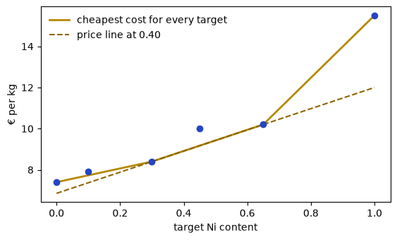

```python
targets = np.linspace(0, 1, 101)
costs = [best_cost(t) for t in targets]
fig, ax = plt.subplots(figsize=(6.4, 3.6))
ax.plot(targets, costs, color=MIN_C, lw=2, label="cheapest cost for every target")
ax.scatter(W, PRICE, color=LOT_C, zorder=3)
ax.plot([0, 1], [base, base + slope], color=LINE_C, ls="--", label="price line at 0.40")
ax.set_xlabel("target Ni content"); ax.set_ylabel("€ per kg"); ax.legend(frameon=False)
plt.show()
```

### Your turn: a new offer

A dealer offers swarf at $w=0.50$ for €9.20 per kg. What is its gap (price minus the line's height at 0.50)? Is it worth buying?

```python
offer_gap = None   # €, with its sign
check(offer_gap, "f4p_offer_gap")
```

```
f4p_offer_gap: not attempted yet. Replace None with your value and run the cell again.
```

*After your attempt.* Add the swarf to the lists and solve again. Checking one new candidate against the line, without solving again, is called pricing; step 13 uses it to find missing states.

```python
res_offer = linprog(np.append(c, 9.20), A_eq=np.column_stack([A_eq, [1.0, 0.50]]), b_eq=b_eq, bounds=(0, None), method="highs-ds")
print(f"with the swarf: {res_offer.fun:.3f} € per kg, amounts {np.round(res_offer.x, 3) + 0.0}")
```

```
with the swarf: 8.800 € per kg, amounts [0.  0.  0.5 0.  0.  0.  0.5]
```

## 5. The textbook picture (main track, 15 min)

Books draw LPs with the amounts on the axes. Take two lots, CuNi30 (amount $f_P$) and Monel (amount $f_Q$), and four rules of the kind melt shops have:

| Rule | In symbols |
| --- | --- |
| the charge weighs at least 1 kg | $f_P+f_Q\ge1$ |
| it holds at least 0.40 kg nickel | $0.30f_P+0.65f_Q\ge0.40$ |
| it holds at most 0.012 kg iron (CuNi30 0.6 %, Monel 2.0 % Fe) | $0.006f_P+0.020f_Q\le0.012$ |
| the furnace holds at most 1.5 kg | $f_P+f_Q\le1.5$ |

`linprog` wants "at most" rules (`A_ub @ f <= b_ub`), so an "at least" rule is multiplied by $-1$. Remember which rows you flipped: their prices flip sign too.

```python
P_PRICE, Q_PRICE = 8.40, 10.20
A_ub = np.array([[-1.0, -1.0],      # weight at least 1 kg, times -1
                 [-0.30, -0.65],    # nickel at least 0.40 kg, times -1
                 [0.006, 0.020],    # iron at most 0.012 kg
                 [1.0, 1.0]])       # furnace at most 1.5 kg
b_ub = np.array([-1.0, -0.40, 0.012, 1.5])
FLIPPED = np.array([-1, -1, 1, 1])  # -1 marks a rule multiplied by -1
RULE_NAMES = ["weight", "nickel", "iron", "furnace"]
poly = linprog([P_PRICE, Q_PRICE], A_ub=A_ub, b_ub=b_ub, bounds=(0, None), method="highs-ds")
print(poly.message)
print(f"buy {poly.x[0]:.3f} kg CuNi30 and {poly.x[1]:.3f} kg Monel, cost {poly.fun:.3f} €")
```

```
Optimization terminated successfully. (HiGHS Status 7: Optimal)
buy 0.714 kg CuNi30 and 0.286 kg Monel, cost 8.914 €
```

**Corners by hand.** Every corner of the allowed region is where two boundary lines meet and every rule holds. Try every pair of lines (the four rules and the two axes), keep the allowed points, and price them.

```python
lines = [(row * s, rhs * s, name) for row, rhs, s, name in zip(A_ub, b_ub, FLIPPED, RULE_NAMES)]
lines += [(np.array([1.0, 0.0]), 0.0, "no CuNi30"), (np.array([0.0, 1.0]), 0.0, "no Monel")]
corners = []
for k in range(len(lines)):
    for m in range(k + 1, len(lines)):
        M = np.array([lines[k][0], lines[m][0]])
        if abs(np.linalg.det(M)) < 1e-12:
            continue                                         # parallel lines never meet
        point = np.linalg.solve(M, [lines[k][1], lines[m][1]])
        if point.min() > -1e-9 and np.all(A_ub @ point <= b_ub + 1e-9):
            corners.append((point, lines[k][2], lines[m][2]))
for point, r1, r2 in corners:
    print(f"({point[0]:.3f}, {point[1]:.3f})  {r1} and {r2} tight   cost {P_PRICE * point[0] + Q_PRICE * point[1]:.3f} €")
```

```
(0.714, 0.286)  weight and nickel tight   cost 8.914 €
(0.571, 0.429)  weight and iron tight   cost 9.171 €
(1.333, 0.000)  nickel and no Monel tight   cost 11.200 €
(1.286, 0.214)  iron and furnace tight   cost 12.986 €
(1.500, 0.000)  furnace and no Monel tight   cost 12.600 €
```

### Your turn: one corner

What does the corner where the weight and iron rules are tight cost?

```python
corner_cost = None   # €
check(corner_cost, "f4p_corner_cost")
```

```
f4p_corner_cost: not attempted yet. Replace None with your value and run the cell again.
```

The picture: the allowed region, the four rule lines and the cheapest cost line. Slide a cost line $8.40f_P+10.20f_Q=C$ towards lower $C$ until it is about to leave the region: it last touches a corner.

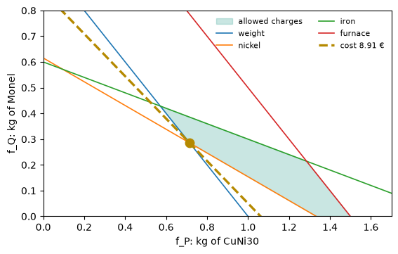

```python
centre = np.mean([p for p, _, _ in corners], axis=0)                       # the polygon's middle
order = np.argsort([np.arctan2(p[1] - centre[1], p[0] - centre[0]) for p, _, _ in corners])
region = np.array([corners[k][0] for k in order])
fig, ax = plt.subplots(figsize=(6.4, 3.8))
ax.fill(region[:, 0], region[:, 1], color="#2a9d8f", alpha=0.25, label="allowed charges")
fp = np.linspace(0, 1.7, 2)
for (row, rhs, name) in lines[:4]:
    ax.plot(fp, (rhs - row[0] * fp) / row[1], lw=1.2, label=name)
ax.plot(fp, (poly.fun - P_PRICE * fp) / Q_PRICE, color=MIN_C, lw=2.4, ls="--", label=f"cost {poly.fun:.2f} €")
ax.plot(*poly.x, "o", color=MIN_C, ms=9)
ax.set_xlim(0, 1.7); ax.set_ylim(0, 0.8)
ax.set_xlabel("f_P: kg of CuNi30"); ax.set_ylabel("f_Q: kg of Monel"); ax.legend(frameon=False, fontsize=8, ncol=2)
plt.show()
```

**Prices and slack.** `res.slack` is the room left in each rule (zero when the rule is tight). `res.ineqlin.marginals` holds the prices; for the rows you multiplied by $-1$, flip the sign back.

```python
for name, room, price, s in zip(RULE_NAMES, poly.slack, poly.ineqlin.marginals, FLIPPED):
    print(f"{name:8s} room left {room:.4f}   price {s * price + 0.0:+.4f} €")   # + 0.0 turns a printed -0.0 into 0.0
```

```
weight   room left 0.0000   price +6.8571 €
nickel   room left 0.0000   price +5.1429 €
iron     room left 0.0020   price +0.0000 €
furnace  room left 0.5000   price +0.0000 €
```

The weight rule costs €6.86 per kg and the nickel rule €5.14 per kg of nickel: the same numbers as the line under the dots in section 4. (More nickel in the same weight swaps copper, worth €6.86, for nickel, worth €12.00: 12.00 − 6.86 = 5.14.) Above 0.45 kg of nickel the iron cap takes over from the weight rule and the nickel price jumps; try it in `b_ub`. Rules with room to spare cost nothing. Make the iron cap strict (0.005 kg) and no charge keeps every rule: `linprog` reports status 2.

```python
strict = linprog([P_PRICE, Q_PRICE], A_ub=A_ub, b_ub=[-1.0, -0.40, 0.005, 1.5], bounds=(0, None), method="highs-ds")
print("strict iron cap: status", strict.status, "-", strict.message)
```

```
strict iron cap: status 2 - The problem is infeasible. (HiGHS Status 8: model_status is Infeasible; primal_status is None)
```

## 6. Same problem, new names: step 10's menu (main track, 5 min)

Rename two columns: Ni content becomes the B atom fraction $x$, price becomes the molar Gibbs energy $g$ in J/mol atoms, and amounts are moles of atoms instead of kilograms (atom fractions instead of mass fractions). Lots become states: one phase model at one composition, the ten dots of step 10's menu. The same `linprog` call then solves step 10, and its two prices are $\mu_A$, the line's height at $x=0$, and $\Delta\mu=\mu_B-\mu_A$, its slope.

One difference matters. Costs add because lots are bought and melted separately. A mixture of menu dots adds energies the same way, as a real sample of separate regions (boundary energy ignored), so the true equilibrium is at or below it: the menu's cheapest mixture is a ceiling. It need not be the truth, because states between the dots are missing: if the atoms of two dots of one phase model form one phase at the average composition, its energy lies on that phase's curve, which can lie below the chord.

```python
from course.self_study import day3_core
models = day3_core.lens_models(1400.0)                     # step 03 part C's melting lens
X = np.array([0.1, 0.3, 0.5, 0.7, 0.9] * 2)                # the menu's compositions, both phases
G = np.array([float(models[p].g(x)) for p in ("SOLID", "LIQUID") for x in X[:5]])   # J/mol atoms
menu = linprog(G, A_eq=np.array([np.ones(10), X]), b_eq=[1.0, 0.40], bounds=(0, None), method="highs-ds")
mu_A, d_mu = menu.eqlin.marginals
print(f"cheapest mixture {menu.fun:.2f} J/mol atoms; mu_A = {mu_A:.1f}, d_mu = {d_mu:.1f} J/mol")
confirm(menu.fun, -20429.542431, "Step 10's cheapest mixture", tol=1e-5)
```

```
cheapest mixture -20429.54 J/mol atoms; mu_A = -19873.9, d_mu = -1389.0 J/mol
✓ Step 10's cheapest mixture reproduces the lesson value.
```

## 7. The companion problem about prices (dive deeper, 10 min)

Every LP has a companion problem, its *dual*. Here it asks: of all straight lines $\text{base}+\text{slope}\times w$ that stay on or below every lot, which is highest at the target? In symbols: maximise $\text{base}+0.40\,\text{slope}$ subject to $\text{base}+\text{slope}\times w_j\le c_j$ for every lot. The two prices are now the variables, and they may be negative (`bounds=(None, None)`). `linprog` only minimises, so minimise the negative and negate the answer.

```python
dual = linprog([-1.0, -TARGET], A_ub=np.column_stack([np.ones(len(W)), W]), b_ub=PRICE,
               bounds=(None, None), method="highs-ds")
print(f"highest line at the target: {-dual.fun:.4f} € (base {dual.x[0]:.4f}, slope {dual.x[1]:.4f})")
print(f"cheapest charge:            {res.fun:.4f} €")
```

```
highest line at the target: 8.9143 € (base 6.8571, slope 5.1429)
cheapest charge:            8.9143 €
```

They meet. Any line under the lots is a floor for every charge (weak duality); the highest one meets the cheapest charge (strong duality). A lot strictly above the best line is never used (complementary slackness).

## 8. Unbounded, and prices that are not unique (dive deeper, 10 min)

**Unbounded.** Drop "no amount is negative": a negative amount means selling a lot you do not have. Then the cost can fall without limit.

```python
free = linprog(c, A_eq=A_eq, b_eq=b_eq, bounds=(None, None), method="highs-ds")
print("amounts may be negative: status", free.status, "-", free.message)
```

```
amounts may be negative: status 3 - The problem is unbounded. (HiGHS Status 10: model_status is Unbounded; primal_status is Feasible)
```

**Prices that are not unique.** Put the target exactly on a used lot, 0.30 (CuNi30). The best charge is clear, 1 kg of CuNi30. But many lines touch the dots there: the price to the left differs from the price to the right, and two solver methods may return different ones.

```python
for method in ("highs-ds", "highs-ipm"):
    r = linprog(c, A_eq=A_eq, b_eq=[1.0, 0.30], bounds=(0, None), method=method)
    print(f"{method:9s} cost {r.fun:.4f} €  amounts {np.round(r.x, 3) + 0.0}  prices {np.round(r.eqlin.marginals, 4)}")
```

```
highs-ds  cost 8.4000 €  amounts [0. 0. 1. 0. 0. 0.]  prices [6.8571 5.1429]
highs-ipm cost 8.4000 €  amounts [0. 0. 1. 0. 0. 0.]  prices [7.4    3.3333]
```

Here: same cost, same amounts, two different slopes (which method returns which can depend on the solver version). Each is a valid line under all lots.

This matters when the list is short. Keep only Cu and Monel and put the target on Monel, 0.65. The best charge is 1 kg Monel; the line through Cu and Monel is one valid answer for the prices. CuNi30 lies below that line, yet 1 kg Monel is already the cheapest charge of all six lots. So with a target on a used lot, a lot below the returned line does not prove that the charge can be improved; step 15 meets this again.

```python
cu, monel, cuni30 = 0, 4, 2                                   # indices into the lists of section 0
slope_cm = (PRICE[monel] - PRICE[cu]) / (W[monel] - W[cu])    # the line through Cu and Monel
gap_cuni30 = PRICE[cuni30] - (PRICE[cu] + slope_cm * W[cuni30])
print(f"short list: 1 kg Monel, {PRICE[monel]:.2f} €; CuNi30 lies {-gap_cuni30:.2f} € below the Cu-Monel line")
print(f"all six lots at 0.65: {best_cost(0.65):.2f} € (still 1 kg Monel)")
```

```
short list: 1 kg Monel, 10.20 €; CuNi30 lies 0.29 € below the Cu-Monel line
all six lots at 0.65: 10.20 € (still 1 kg Monel)
```

## 9. Exercises (both tracks, 20 min)

**Exercise 1 (main).** Make 2 kg of solder with at least 1.2 kg of tin, from alloy A (0.5 tin, €20 per kg) and alloy B (0.7 tin, €26 per kg), as cheaply as possible. Write it for `linprog` and give the best cost.

```python
solder_cost = None   # €
check(solder_cost, "f4p_solder_cost")
```

```
f4p_solder_cost: not attempted yet. Replace None with your value and run the cell again.
```

**Exercise 2 (main).** In the textbook picture, Monel costs €8.00 instead of €10.20. What does the cheapest charge cost now? Which rules are tight?

```python
monel8_cost = None   # €
check(monel8_cost, "f4p_monel8_cost")
```

```
f4p_monel8_cost: not attempted yet. Replace None with your value and run the cell again.
```

*After your attempt.*

```python
solder = linprog([20.0, 26.0], A_eq=[[1.0, 1.0]], b_eq=[2.0], A_ub=[[-0.5, -0.7]], b_ub=[-1.2],
                 bounds=(0, None), method="highs-ds")
print(f"solder: {solder.x.round(3)} kg, {solder.fun:.2f} €")
cheap = linprog([P_PRICE, 8.00], A_ub=A_ub, b_ub=b_ub, bounds=(0, None), method="highs-ds")
print(f"Monel at €8.00: {cheap.x.round(3)} kg, {cheap.fun:.3f} €; tight: "
      + ", ".join(n for n, room in zip(RULE_NAMES, cheap.slack) if room < 1e-9))
```

```
solder: [1. 1.] kg, 46.00 €
```

```
Monel at €8.00: [0.571 0.429] kg, 8.229 €; tight: weight, iron
```

## What you have done

- You wrote a linear programme in plain words and in `linprog`'s arrays.
- You read its status, amounts, best total and prices, and checked them: the rules hold, nothing is negative, and a line under every lot proves that nothing is cheaper.
- You saw that a price holds only while the same lots stay in use, and that it can be non-unique when the target sits on a used lot.
- With two columns renamed, the same call solved step 10's menu. Continue with step 10 on the website, or notebook f4c for its code.